# Market Power

Lecture 6

Div Bhagia

# Monopoly

## Monopoly and Market Power

- **Monopoly**: single seller of a good with no close substitutes
- **Market power**: ability to set price above marginal cost
- Monopolists face a downward-sloping demand curve (knows it can influence the market price)
- Monopoly leads to higher prices, lower output, and deadweight loss compared to perfect competition

## Perfectly Competitive Firm vs. Monopolist

A **perfectly competitive firm**’s problem:
$$\max_q \; P \cdot q - C(q)$$

First-order condition:
$$P = MC(q)$$

A **monopolist**’s problem:
$$\max_Q \; P(Q) \cdot Q - C(Q)$$
First-order condition:
$$\underbrace{P(Q) + Q \cdot P'(Q)}_{MR(Q)} = MC(Q)$$

**Why are price and marginal revenue different for a monopolist?**

## Monopoly Equilibrium

Monopolist maximizes:
$$\max_Q \; \pi(Q) = P(Q) \cdot Q - C(Q)$$

First-order condition:
$$\frac{d\pi}{dQ} = MR(Q) - MC(Q) = 0$$

Where marginal revenue is:
$$MR(Q) = \underbrace{P(Q)}_{\text{output effect}} + \underbrace{Q \cdot P'(Q)}_{\text{price effect}}$$

Since $P'(Q) < 0$, we always have $MR(Q) < P(Q)$. The monopolist produces where $MR(Q^*_m) = MC(Q^*_m)$, then charges $P^*_m = P(Q^*_m) > MC$.

## Monopoly Equilibrium on a Graph

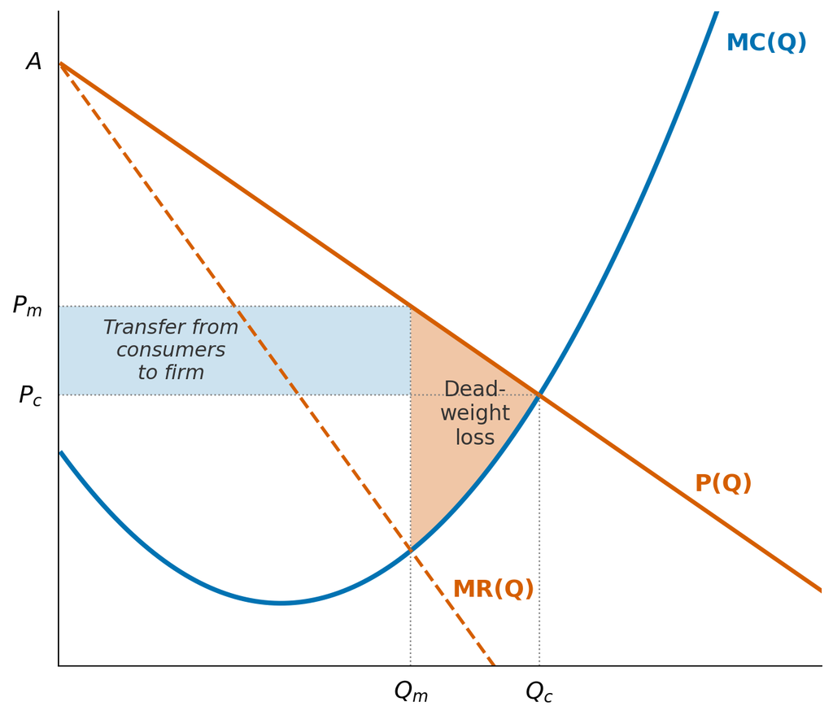

## The Inverse Elasticity Rule

From $MR = P + Q \cdot P'(Q)$, we can express marginal revenue in terms of the price elasticity of demand $\varepsilon_D$:

$$MR = P\!\left(1 + \frac{1}{\varepsilon_D}\right) = P\!\left(1 - \frac{1}{|\varepsilon_D|}\right)$$

Setting $MR = MC$:

$$\boxed{\frac{P - MC}{P} = \frac{1}{|\varepsilon_D|}}$$

The **Lerner Index** (markup over price) equals the inverse of the absolute elasticity. More inelastic demand → larger markup.

## Question: Monopoly Pricing and Elasticity

If demand curve takes constant elasticity form $Q = a P^{-\varepsilon}$ and marginal cost is constant at $c$, what price will the monopolist charge?

- Write the profit-maximization problem and derive the first-order condition.
- Solve for the optimal price $P^*$ in terms of $c$ and $\varepsilon$.

## Monopolies Around You

- Can you think of any real-world examples of monopolies or firms with significant market power? What do you think prevents other firms from entering these markets?
- Do you think these monopolistic firms charge prices above marginal cost?

## Sources of Monopoly Power

- **Technical Barriers**
  - Economies of scale: high fixed costs e.g. utilities
  - Control of key inputs: e.g., Standard Oil (controlled ~90% of US oil refining by 1880s)
  - Network effects: value rises with users (platforms, os)
- **Legal Barriers**
  - Patents & IP: pharmaceutical exclusivity periods
  - Government franchises: postal services
  - Licensing & regulation: spectrum allocation, taxi medallions
- **Strategic Behavior**
  - Predatory pricing: price below cost to deter entry
  - Exclusive contracts: lock up distribution channels
  - Excess capacity: credible threat of aggressive response

# Price Discrimination

## Price Discrimination

- A monopoly may be able to increase profits by departing from a single-price policy for its output
- Charging different prices to different consumers for the same good is called **price discrimination**
- When is price discrimination feasible? Can it be profitable? What are the welfare implications?
- Three degrees of price discrimination: first-degree (perfect), second-degree (screening), third-degree (segmentation)

## First-Degree (Perfect)

- Charge each consumer their maximum willingness to pay for each unit.
- Output = competitive level, no deadweight loss, but all surplus goes to the firm.
- Requires perfect information, which is rare in practice. Examples?

## Second-Degree (Screening)

- Offer a menu of options and let consumers self-select. Price varies by quantity or version.
- Mechanisms:
  - Block pricing: different per-unit price by quantity tier (electricity bills, bulk discounts)
  - Bundling: sell products as a package (Microsoft Office, cable TV, meal deals)
  - Versioning: same product at degraded vs. premium tiers (Spotify Free/Premium, economy/business class)
  - Two-part tariffs: fixed fee + per-unit price (Costco membership, gym + class fees)

## Third-Degree (Segmentation)

Do we think this is generally welfare-improving?

# Imperfect Competition

## The Space Between

**Most markets are neither perfect competition nor monopoly.**

- A few large airlines dominate routes
- Coca-Cola and Pepsi in soft drinks
- Samsung and Apple in smartphones
- OPEC countries in oil production

**Oligopoly:** A market with a small number of firms whose decisions are **interdependent** i.e. each firm’s optimal choice depends on what the others do.

How do firms compete in oligopoly? How do they react to each other’s actions? **Do they set prices or quantities?**

## Nash Equilibrium

- Before we move on, we will define one concept from **game theory** that will be useful for analyzing oligopoly: **Nash equilibrium**.
- **Game theory** studies strategic interactions between rational decision-makers and hence is a natural tool for analyzing oligopoly where firms’ decisions are interdependent.
- A **Nash equilibrium** is a set of strategies (one for each player) such that no player can improve their payoff by unilaterally changing their strategy, given the strategies of the others.

# Price Competition

## Bertrand Model

**Setup:**

- Two firms produce a **homogeneous** (identical) good
- Each firm simultaneously chooses a **price**
- Consumers buy from the firm with the lowest price (if equal, split the market)
- Both firms have constant marginal cost $c$

**Key question:** What prices will the firms choose?

## Bertrand: Reasoning

**Suppose firm 1 sets $p_1 > c$.**

- Firm 2 can capture the **entire market** by setting $p_2 = p_1 - \epsilon$
- But then firm 1 would want to undercut firm 2…
- This undercutting continues until…

**Nash equilibrium:** $p_1^* = p_2^* = c$

Both firms price at marginal cost reaching the **competitive outcome** (with just two firms!)

This is the **Bertrand paradox**: two firms are enough to eliminate all market power.

## Bertrand: Verifying the Equilibrium

Why is $p_1^* = p_2^* = c$ a Nash equilibrium?

**Can either firm profit by deviating?**

- **Raise price?** You lose all customers (rival still charges $c$). Profit stays at $0$.
- **Lower price?** You get the whole market, but sell below cost. Profit is *negative*.

No profitable deviation exists. ✓

**Why can’t $p_1 = p_2 > c$ be an equilibrium?**

Either firm could undercut by $\epsilon$ and capture the entire market, roughly doubling its profit.

## What Resolves the Bertrand Paradox?

Real oligopolies earn positive profits. The Bertrand model misses something. Key extensions:

- **Capacity constraints**: firms can’t always serve the whole market
- **Product differentiation**: goods aren’t identical, so undercutting doesn’t capture everyone
- **Repeated interaction**:firms can sustain higher prices through tacit collusion
- **Quantity competition**: choosing quantities instead of prices changes things fundamentally

# Quantity Competition

## Cournot Model

**Setup:**

- Two firms produce a **homogeneous** good
- Each firm simultaneously chooses a **quantity**
- Market price determined by inverse demand: $P = a - b(q_1 + q_2)$
- Both firms have constant marginal cost $c$

**Key difference from Bertrand:** Firms commit to production levels, and the market clears at whatever price equates demand and supply.

## Cournot: Firm’s Problem

**Firm 1 maximizes:**
$$\pi_1 = P \cdot q_1 - c \cdot q_1 = [a - b(q_1 + q_2)]q_1 - cq_1$$

**FOC:**
$$\frac{\partial \pi_1}{\partial q_1} = a - 2bq_1 - bq_2 - c = 0$$

**Best response function:**
$$q_1^*(q_2) = \frac{a - c}{2b} - \frac{q_2}{2}$$

By symmetry: $q_2^*(q_1) = \frac{a - c}{2b} - \frac{q_1}{2}$

## Cournot: Solving for Equilibrium

In a symmetric equilibrium, $q_1 = q_2 = q^*$:

$$q^* = \frac{a - c}{2b} - \frac{q^*}{2} \implies q^* = \frac{a - c}{3b}$$

**Total output:** $Q^* = 2q^* = \frac{2(a-c)}{3b}$

**Price:** $P^* = a - bQ^* = \frac{a + 2c}{3}$

**Profit per firm:** $\pi^* = (P^* - c) q^* = \frac{(a-c)^2}{9b}$

**Note:** $P^* > c$, so firms earn positive profits unlike Bertrand!

## Cournot vs. Competition vs. Monopoly

|  | Price | Total Output | Profit |
| --- | --- | --- | --- |
| **Competition** | $c$ | $(a-c)/b$ | $0$ |
| **Cournot** | $(a+2c)/3$ | $2(a-c)/(3b)$ | $(a-c)^2/(9b)$ |
| **Monopoly** | $(a+c)/2$ | $(a-c)/(2b)$ | $(a-c)^2/(4b)$ |

Cournot lies **between** competition and monopoly.

## Worked Example

**Demand:** $P = 100 - Q$, where $Q = q_1 + q_2$. Both firms have $MC = 20$.

**Firm 1’s best response:**
$$q_1^* = \frac{100 - 20 - q_2}{2} = 40 - \frac{q_2}{2}$$

**Symmetric equilibrium:** $q^* = 40 - q^*/2 \implies q^* = 80/3 \approx 26.67$

**Total output:** $Q^* \approx 53.33$

**Price:** $P^* \approx \$46.67$

**Profit per firm:** $\pi^* = (46.67 - 20)(26.67) \approx \$711$

Compare: Monopoly profit = $\$1{,}600$, so total Cournot profit ($\$1{,}422$) is less.

## Cournot: Best Response Functions

[figure not shown]

## Why Is the Collusion Point Not an Equilibrium?

At the collusion point, each firm produces $q_m/2 = 20$ and earns $\$800$.

**But from firm 1’s perspective:** If firm 2 is producing $20$, firm 1’s best response is:

$$q_1^* = 40 - \frac{20}{2} = 30$$

Firm 1 can earn **more** by producing 30 instead of 20. Each firm has an incentive to **cheat** on the collusive agreement. This is essentially a **Prisoner’s Dilemma** (we will talk about when we cover game theory).

## Cournot with $n$ Firms

With $n$ identical firms, the symmetric equilibrium:

$$q^* = \frac{a - c}{(n+1)b}, \qquad Q^* = \frac{n(a - c)}{(n+1)b}, \qquad P^* = \frac{a + nc}{n+1}$$

**Lerner index:**
$$L = \frac{P^* - c}{P^*} = \frac{a - c}{a + nc}$$

As $n \to \infty$: $P^* \to c$ **converges to perfect competition**

As $n = 1$: reduces to **monopoly**

## Convergence to Competition

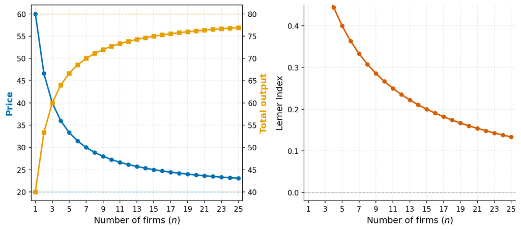